# Task 3

Hannes Guth

2023-03-06

```r
library(fpp3) # package for tsibble
library(ggplot2) # package for plots
library(lubridate) # package to handle dates
library(data.table) # package to store data in a data table
library(dplyr) # package for pipe operator
```

## 1.

### Plot and analyse the data. Is there any seasonality? If yes, how it can be characterized? If no, why? Justify your answer.

At first, the date needs to transformed to the correct data type. Also, a column “weekDay” will be introduced.

```r
Sys.setlocale("LC_TIME", "en_US") # change the language to English so that the week days later
```

```
## [1] "en_US"
```

```r
webtraffic <- fread("webtraffic.csv") # load the data set
webtraffic$Day = as.Date(webtraffic$Day, format = "%d.%m.%Y") # transform the time information into a date format
webtraffic$weekDay = format(as.Date(webtraffic$Day, format = "%a")) # extract the weekday
webtraffic$weekDay = weekdays(webtraffic$Day, abbreviate = TRUE) # abbreviate the weekday
```

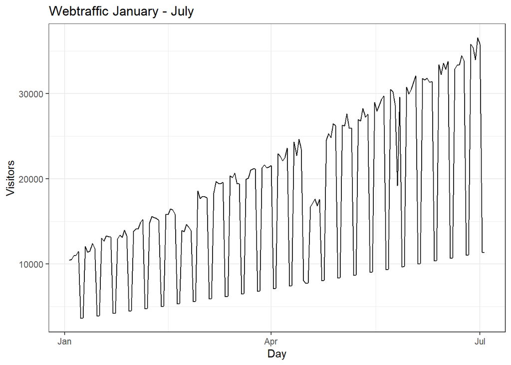

```r
ggplot(webtraffic, aes(x = Day, y = Visitors, group = 1)) + # create a new ggplot with Day on the x axis and Visitors on the y-axis
  geom_path() + # show the path
  labs(title = "Webtraffic January - July") + # set the title
  theme_bw() # use the theme bw
```

One can observe a seasonality where 2 datapoints (2 days) have much lower levels of visitors than the rest of one segment. The expectation is the lower points belong to days of the weekend but this cannot be seen here and will be visualised in th next graph. Besides, there is an overall positive trend and the amplitudes seem to become bigger.

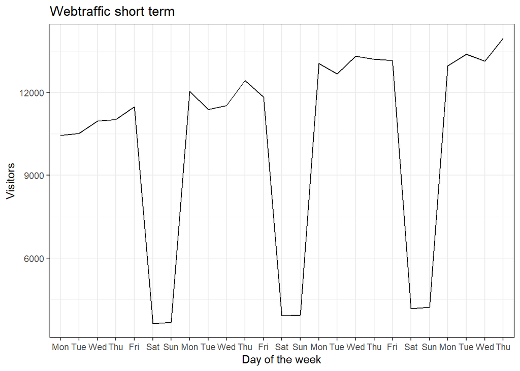

```r
ggplot(webtraffic[1:25,], aes(x = reorder(Day, weekDay), y = Visitors, group = 1)) + # create a new ggplot for a shorter period
  geom_path() + # show the path
  labs(title = "Webtraffic short term", x = "Day of the week") + # change the labels
  scale_x_discrete(labels = webtraffic$weekDay) + # edit the x-axis labels
  theme(axis.text.x = element_text(angle = 45, vjust = 0.5, hjust=1)) + # adapt the x-axis labels
  theme_bw() # use the theme bw
```

The expectation could be confirmed, the lower levels of visitors belong to days of the weekend.

## 2.

### Make a time series decomposition applying additive and multiplicative models.

#### Additive model

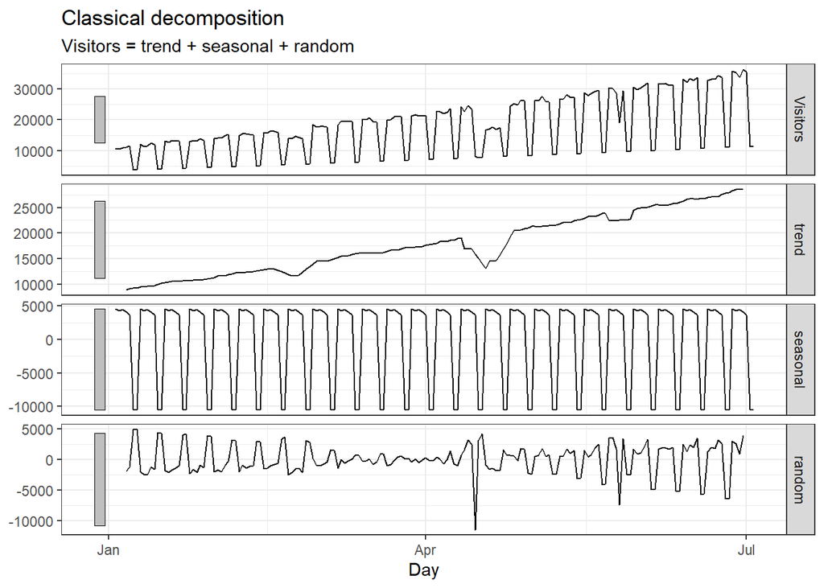

```r
webtsibble = as_tsibble(webtraffic, index = Day) # transform webtraffic to a tsibble

# apply the additive model for the timeseries
dec_additive = webtsibble %>%
  model(
    classical_decomposition(Visitors, type = "additive")
  )

additive <- components(dec_additive) # decompose the single components

additive %>% autoplot() + theme_bw() # plot the single components and use the theme bw
```

One can observe an overall linear positive trend with a light depression in February - March and bigger one a the end of April. Seasonality is visible as described in 1.

#### Multiplicative model

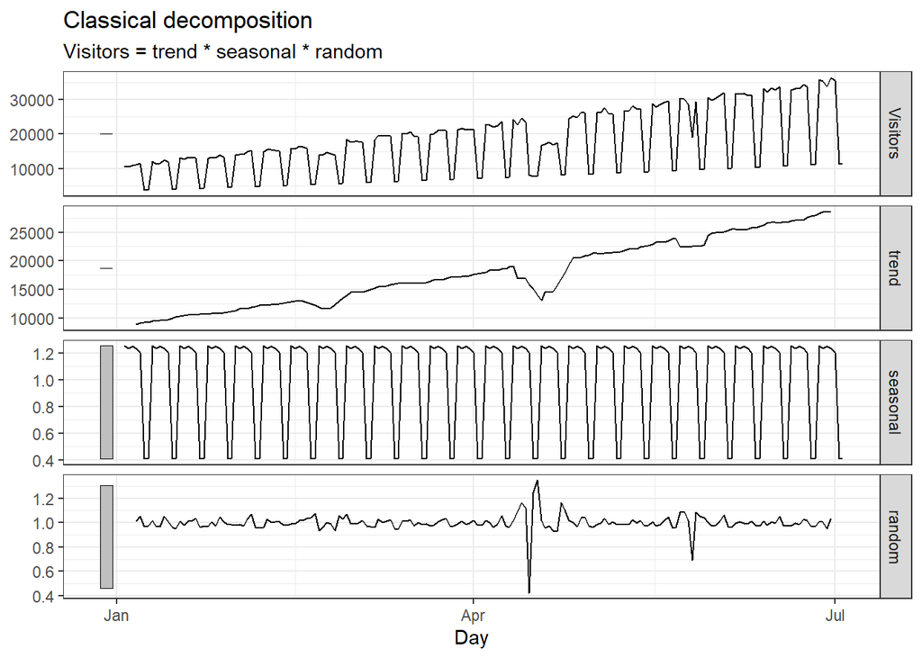

```r
# apply the multiplicative model for the timeseries
dec_multiplicative = webtsibble %>%
  model(
    classical_decomposition(Visitors, type = "multiplicative")
  )

multiplicative <- components(dec_multiplicative) # decompose the single components

multiplicative %>% autoplot() + theme_bw() # plot the single components and use the theme bw
```

The linear trend that was seen in the additive model can be found here as well. The random error seems to more at random than in the additive model where it seemed to be in relation with the seasonality.

## 3.

### Repeat the decomposition using the stl approach. Which decomposition seems to be most relevant to the data?

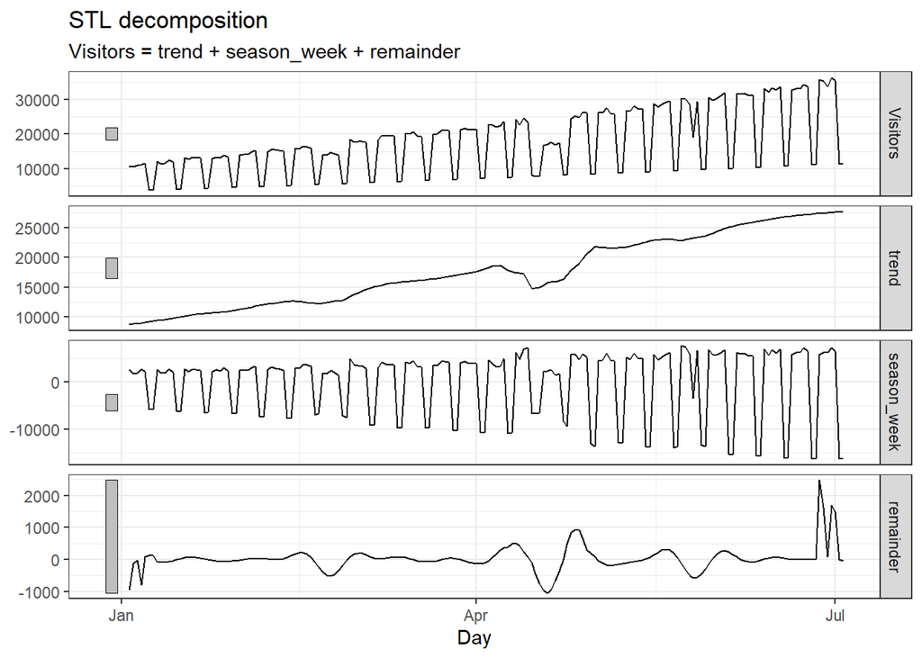

```r
# apply the STL model for the timeseries
dec_stl = webtsibble %>%
  model(
    STL(Visitors ~ trend(window = 15) + season(window = 2),
        robust = TRUE)
  )

stl <- components(dec_stl) # decompose the single components

stl %>% autoplot() + theme_bw() # plot the single components
```

The seasonal (week) decomposition seems to be most characteristic for the data because the obvious forms of the overall timeseries and the seasonality are most similar.

## 4.

### Extract trend component from each of three decompositions. Make a comparison by plotting it on the data plot. Do trends components differ? Why? Justify your answer.

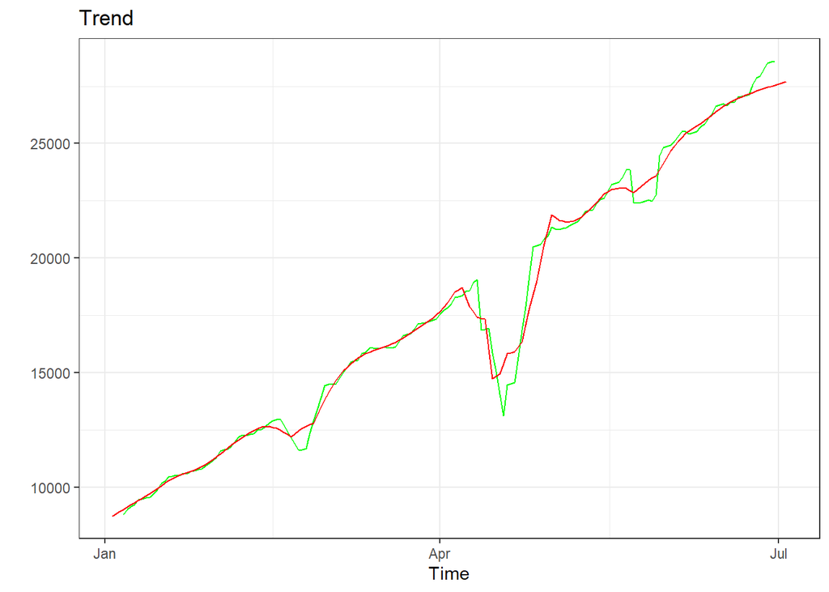

```r
# extract the trend from the different models
trends = data.table("Day" = additive$Day,
                    "Additive" = additive$trend,
                    "Multiplicative" = multiplicative$trend,
                    "STL" = stl$trend)

ggplot(trends, aes(x = Day)) + # create a new ggplot with the trends
  geom_line(aes(y=Additive), color = "black") + # plot the trend for the additive model
  geom_line(aes(y=Multiplicative), color = "green") + # plot the trend for the multiplicative model
  geom_line(aes(y=STL), color = "red") + # plot the trend for the STL model
  labs(title = "Trend", y = "", x = "Time") + # set the labels
  theme_bw() # use the bw theme
```

The trends from the additive and the multiplicative model are the same, therefore, the one from the additive model disappears completely behind the multiplicative one. The trend from the STL approach is also similar but seems to be more smooth than the first two.

## 5.

### Extract seasonal component from each of three decompositions. Make a comparison. Do seasonal components differ? Provide a detailed comment on your findings.

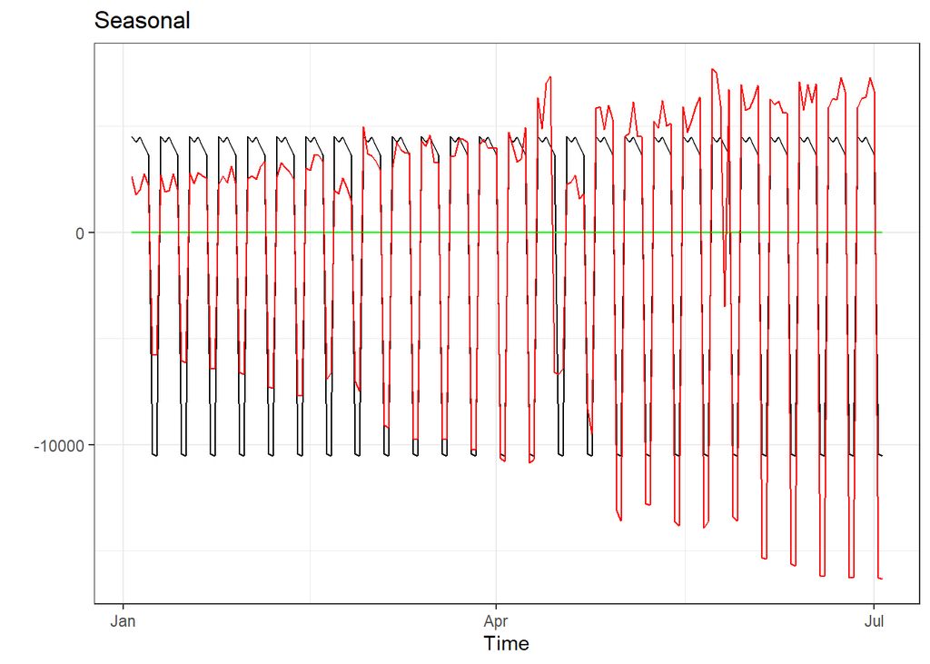

```r
# extract the trend from the different models
seasonal = data.table("Day" = additive$Day,
                      "Additive" = additive$seasonal,
                      "Multiplicative" = multiplicative$seasonal,
                      "STL" = stl$season_week)

ggplot(seasonal, aes(x = Day)) + # create a new ggplot with the trends
  geom_line(aes(y=Additive), color = "black") + # plot the trend for the additive model
  geom_line(aes(y=Multiplicative), color = "green") + # plot the trend for the multiplicative model
  geom_line(aes(y=STL), color = "red") + # plot the trend for the STL model
  labs(title = "Seasonal", y = "", x = "Time")  + # set the labels
  theme_bw() # use the bw theme
```

```r
# show the summaries of the seasonalities of the different models
summary(additive$seasonal)
```

```
##    Min. 1st Qu.  Median    Mean 3rd Qu.    Max.
##  -10537  -10450    4074       0    4482    4519
```

```r
summary(multiplicative$seasonal)
```

```
##    Min. 1st Qu.  Median    Mean 3rd Qu.    Max.
##  0.4091  0.4092  1.2362  1.0000  1.2510  1.2523
```

```r
summary(stl$season_week)
```

```
##     Min.  1st Qu.   Median     Mean  3rd Qu.     Max.
## -16317.2  -6557.3   2988.5    -56.3   4984.1   7728.2
```

## References

### Packages

Hyndman R (2023). *fpp3: Data for “Forecasting: Principles and Practice” (3rd Edition)*. R package version 0.5, https://CRAN.R-project.org/package=fpp3.

H. Wickham. ggplot2: Elegant Graphics for Data Analysis. Springer-Verlag New York, 2016.

Garrett Grolemund, Hadley Wickham (2011). Dates and Times Made Easy with lubridate. Journal of Statistical Software, 40(3), 1-25. URL https://www.jstatsoft.org/v40/i03/.

Dowle M, Srinivasan A (2021). *data.table: Extension of `data.frame`*. R package version 1.14.2, https://CRAN.R-project.org/package=data.table.

Wickham H, François R, Henry L, Müller K (2022). *dplyr: A Grammar of Data Manipulation*. R package version 1.0.10, https://CRAN.R-project.org/package=dplyr.